# LCA*: Past Analyses

Niels Hanson

November 28, 2014

Here I’ve put some previous analyses for posterity’s sake.

#### Formatting for R

- `create_analysis_table.py` summarizes results into a Long Table format that can be processed by R:

```
python create_analysis_table.py -i lca_star_test/metapathways_out/lca_star_test1/preprocessed/lca_star_test1.mapping.txt --ft_table lca_star_test/metapathways_out/lca_star_test1/results/annotation_table/functional_and_taxonomic_table.txt --sum_table lca_star_test/ncbi_bacteria_genomes/ncbi/summary.txt --ncbi_tree ~/Dropbox/utilities/tree_update/data/pipeline/ncbi_taxonomy_tree.txt -o test.out.txt
```

- example output:

```
shebop:lca_star_test nielsh$ head first_test.txt
contig  real    taxa    method  dist
lca_star_test1_378  Desulfovibrio desulfuricans subsp. desulfuricans str. ATCC 27774    Desulfomonas Moore et al. 1976  LCA_Star    3
lca_star_test1_378  Desulfovibrio desulfuricans subsp. desulfuricans str. ATCC 27774    all Majority    11
lca_star_test1_378  Desulfovibrio desulfuricans subsp. desulfuricans str. ATCC 27774    biota   LCA_Squared 10
lca_star_test1_379  Desulfovibrio desulfuricans subsp. desulfuricans str. ATCC 27774    Vibrio cholinicus   LCA_Star    2
lca_star_test1_379  Desulfovibrio desulfuricans subsp. desulfuricans str. ATCC 27774    Vibrio cholinicus   Majority    2
lca_star_test1_379  Desulfovibrio desulfuricans subsp. desulfuricans str. ATCC 27774    Desulfomonas Moore et al. 1976  LCA_Squared 3
lca_star_test1_372  Desulfovibrio desulfuricans subsp. desulfuricans str. ATCC 27774    Desulfomonas Moore et al. 1976  LCA_Star    3
lca_star_test1_372  Desulfovibrio desulfuricans subsp. desulfuricans str. ATCC 27774    all Majority    11
lca_star_test1_372  Desulfovibrio desulfuricans subsp. desulfuricans str. ATCC 27774    'Desulfovibrionaceae'   LCA_Squared 4
```

- a function `lcastar.get_distance(taxon, real)` was added to the LCAStar.py class to calculate a simple distance between taxa.

### Preliminary statistics

First, load required libraries.

```r
library(ggplot2)
library(reshape2)
library(dplyr)
```

#### First test

Here compared our first implementation (March 16 2014) of LCA* using the `lca_star_test1.fasta` above (10,000, sampling 10 sequences per file on a random subset of 100):

```r
data <- read.table("~/Dropbox/projects/LCAStar/lca_star_test1.txt", sep="\t", header=T)

clean_up_data <- function(data) {
  # clean up the dataset factors
  data$dist <- as.numeric(as.character(data$dist))
  data$wtd <- as.numeric(as.character(data$wtd))
  data$method <- as.vector(data$method)

  data$method[data$method=="LCA_Squared"] = "LCA^2"
  data$method[data$method=="Majority"] = "Simple Majority"
  data$method[data$method=="LCA_Star"] = "LCA*"

  # refactor the of methods
  data$method <- factor(data$method, levels = c("LCA^2", "Simple Majority", "LCA*"))

  # clean up column names
  col <- colnames(data)
  col[col == "method"] = "Method"
  col[col == "dist"] = "Walk"
  col[col == "wtd"] = "WTD"
  colnames(data) <- col

  # return the data
  return(data)
}

data <- clean_up_data(data)
data.m <- melt(data)
theme_set(theme_bw())
```

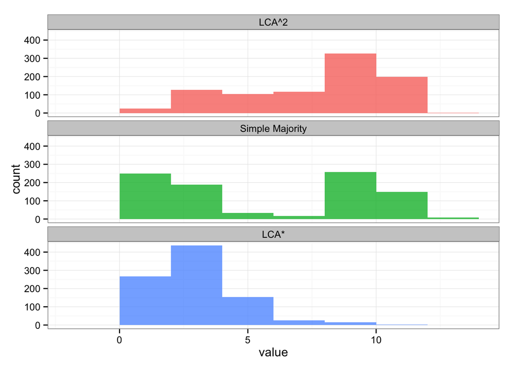

```r
g1 <- ggplot(subset(data.m, variable=="Walk"), aes(x=value))
g1 <- g1 + geom_histogram(binwidth=2, aes(fill=Method), alpha=0.8)
g1 <- g1 + facet_wrap(~ Method, ncol=1)
g1 <- g1 + theme(legend.position="none")
g1
```

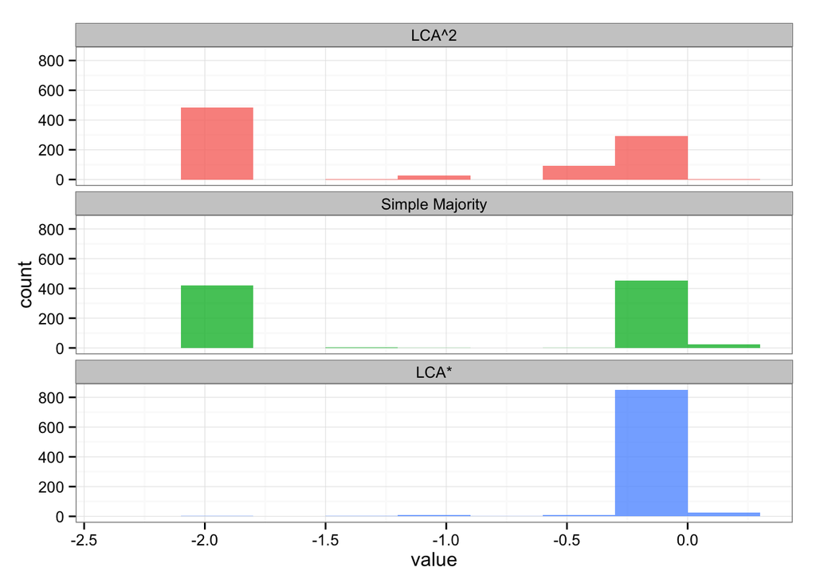

```r
g2 <- ggplot(subset(data.m, variable=="WTD"), aes(x=value))
g2 <- g2 + geom_histogram(binwidth = 0.3, aes(fill=Method), alpha=0.8)
g2 <- g2 + facet_wrap(~ Method, ncol=1)
g2 <- g2 + theme(legend.position="none")
g2
```

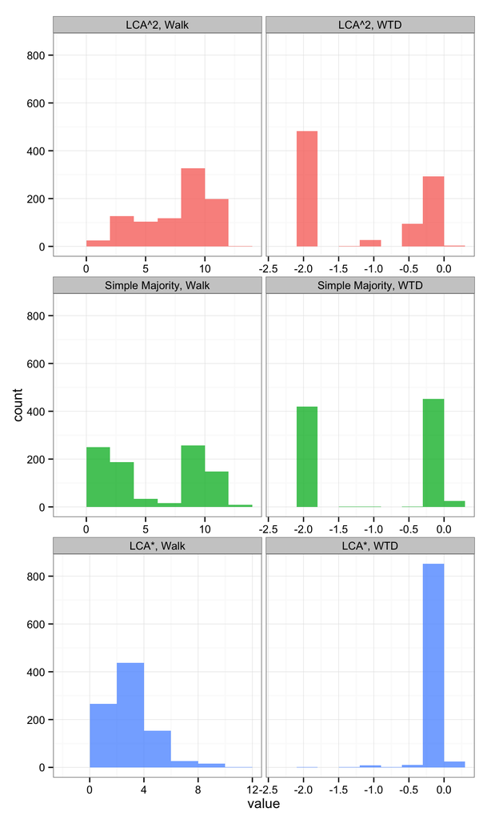

```r
g3 <- ggplot(data.m, aes(x=value, fill=Method))
g3 <- g3 + geom_histogram(data = subset(data.m, variable == "Walk"), binwidth=2, alpha=0.8)
g3 <- g3 + geom_histogram(data = subset(data.m, variable == "WTD"), binwidth=0.3, alpha=0.8)
g3 <- g3 + facet_wrap(Method ~ variable , scale="free_x", ncol = 2)
g3 <- g3 + theme(legend.position="none")
g3
```

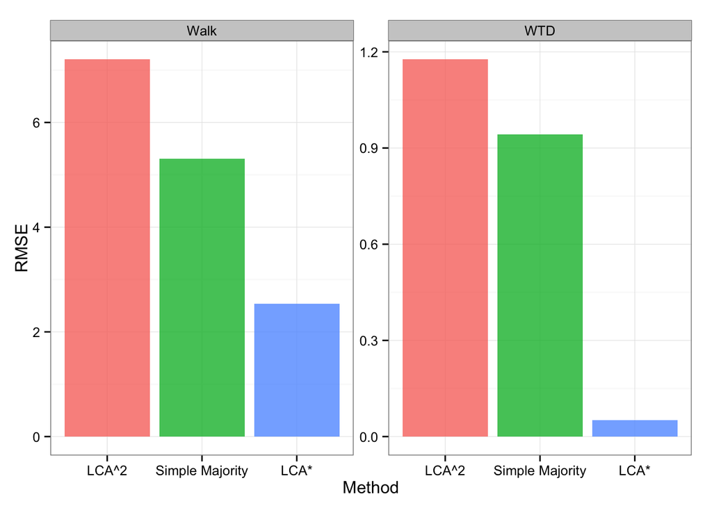

```r
# looking at the RMSE
res <- select(data.m, Method, variable, value) %>%
    group_by(Method, variable) %>%
    summarize(n_obs = n(), RMSE = mean(abs(value), na.rm=TRUE))
g4 <- ggplot(res, aes(y=RMSE, x =Method, fill=Method))
g4 <- g4 + geom_bar(stat="identity", alpha=0.8)
g4 <- g4 + facet_wrap(~variable, scales="free_y")
g4 <- g4 + theme(legend.position="none")
g4
```

### Notes

- The results are encouraging as LCA star seems to have ‘significantly’ smaller distances compared to the other two methods, meaning it is more specific. Though this first distance metric a small distance might still be divergent which we would like to keep track off.
- Doing some basic delcation by taxa we see that within taxonomic groups LCA* seems to do better on this small subset, however, in some cases, namely Green sulfur bacteria and actinobacteria LCA* was outperformed by the simple Majority rule.
- Here it would be interesting to compare their divergence, as it is conseavable that a simple majority make quite have significant divergence when wrong and having extreme wins when it is correct.

```
python create_analysis_table.py -i lca_star_test/metapathways_out/lca_star_test2/preprocessed/lca_star_test2.mapping.txt --ft_table lca_star_test/metapathways_out/lca_star_test2/results/annotation_table/functional_and_taxonomic_table.txt --sum_table lca_star_test/ncbi_bacteria_genomes/ncbi/summary.txt --ncbi_tree ~/Dropbox/utilities/tree_update/data/pipeline/ncbi_taxonomy_tree.txt -o lca_star_test2_lin.txt
```

```r
data2 <- read.table("~/Dropbox/projects/LCAStar/lca_star_test2.txt", sep="\t", quote=c("\"", "\'"), header=T)
data2 <- clean_up_data(data2)
data2.m <- melt(data2)
# remove some outliers
data2.m <- subset(data2.m, value <= 15)
```

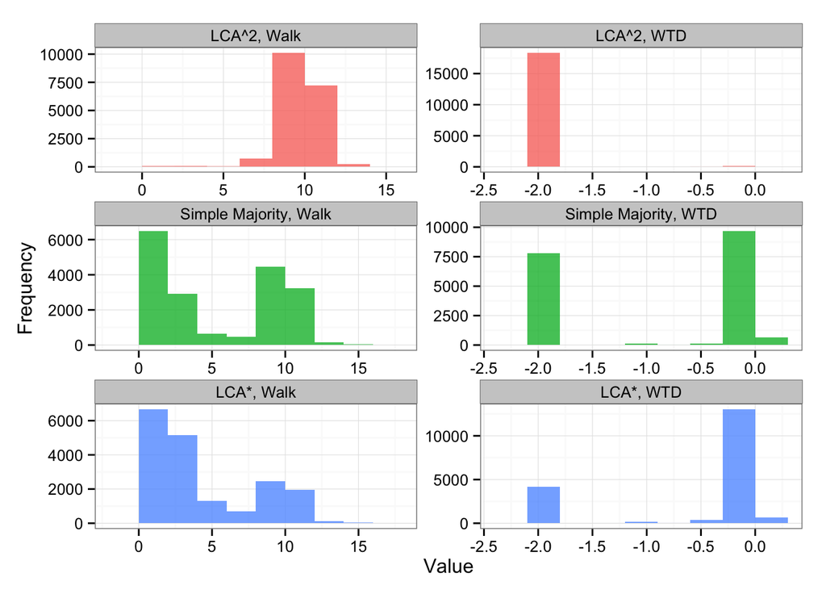

```r
g5 <- ggplot(data2.m, aes(x=value, fill=Method))
g5 <- g5 + geom_histogram(data = subset(data2.m, variable == "Walk"), binwidth=2, alpha=0.8)
g5 <- g5 + geom_histogram(data = subset(data2.m, variable == "WTD"), binwidth=0.3, alpha=0.8)
g5 <- g5 + facet_wrap(Method ~ variable , scale="free", ncol = 2)
g5 <- g5 + theme(legend.position="none")
g5 <- g5 + xlab("Value")
g5 <- g5 + ylab("Frequency")
g5
```

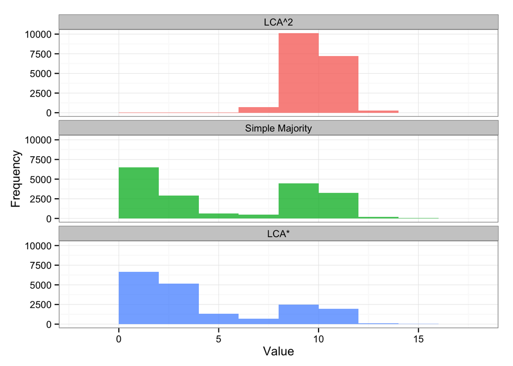

```r
g5a <- ggplot(subset(data2.m, variable == "Walk"), aes(x=value, fill=Method))
g5a <- g5a + geom_histogram(binwidth=2, alpha=0.8)
g5a <- g5a + facet_wrap( ~ Method, ncol = 1)
g5a <- g5a + theme(legend.position="none")
g5a <- g5a + xlab("Value")
g5a <- g5a + ylab("Frequency")
g5a
```

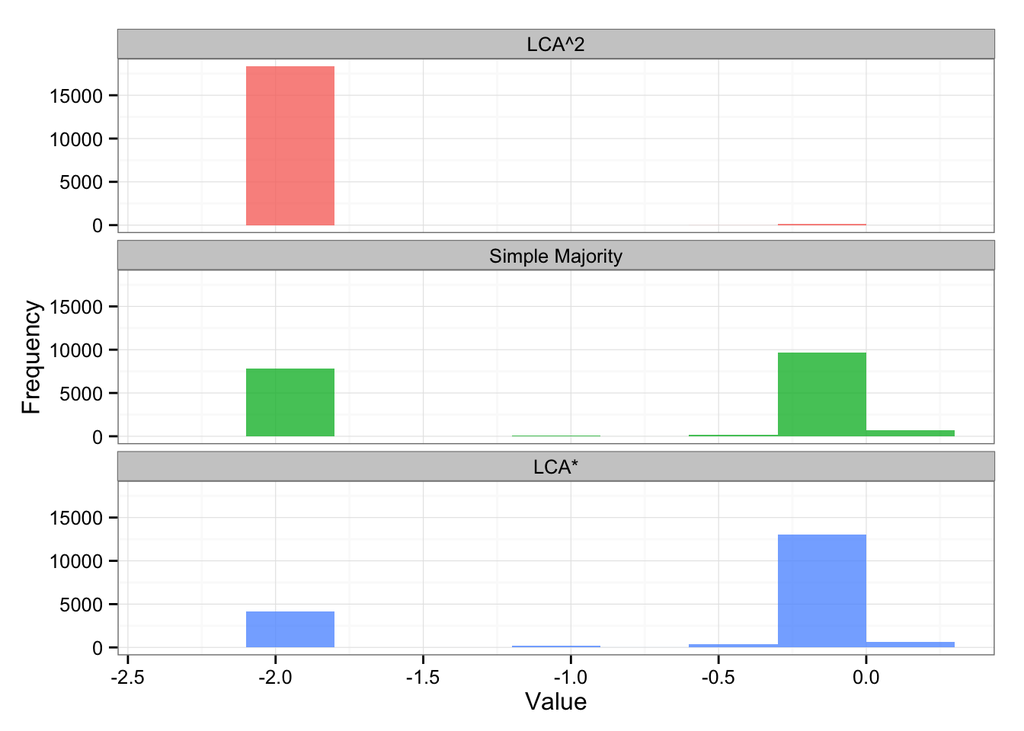

```r
g5b <- ggplot(subset(data2.m, variable == "WTD"), aes(x=value, fill=Method))
g5b <- g5b + geom_histogram(binwidth=0.3, alpha=0.8)
g5b <- g5b + facet_wrap( ~ Method, ncol = 1)
g5b <- g5b + theme(legend.position="none")
g5b <- g5b + xlab("Value")
g5b <- g5b + ylab("Frequency")
g5b
```

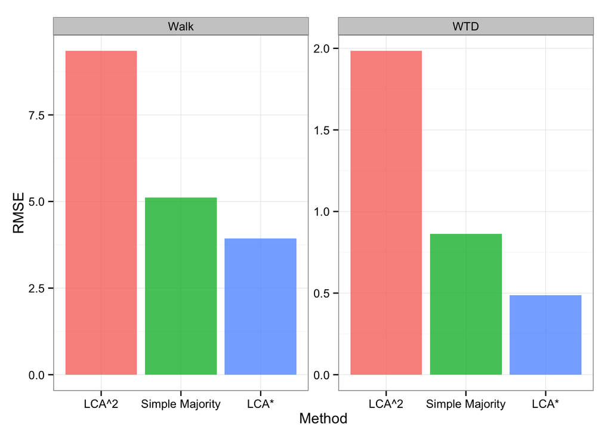

```r
# looking at the RMSE
res <- select(data2.m, Method, variable, value) %>%
    group_by(Method, variable) %>%
    summarize(n_obs = n(), RMSE = mean(abs(value), na.rm=TRUE))
g6 <- ggplot(res, aes(y=RMSE, x =Method, fill=Method))
g6 <- g6 + geom_bar(stat="identity", alpha=0.8)
g6 <- g6 + facet_wrap(~variable, scales="free_y")
g6 <- g6 + theme(legend.position="none")
g6
```

```r
#select(data2.m, Method, variable, value) %>%
#  group_by(Method, variable)
```